# Лабораторная работа №8

Модель конкуренции двух фирм

Разанацуа Сара Естэлл

Российский университет дружбы народов, Москва, Россия

# Информация

## Докладчик

# Вводная часть

## Цель работы

Исследовать математическую модель конкуренции двух фирм.

## Задача

*Случай 1*

Также введена нормировка *t* = *c*<sub>1</sub>*θ*.

## Задача

*Случай 2*

## Задача

*M*<sub>0</sub><sup>1</sup> = 7.3, *M*<sub>0</sub><sup>2</sup> = 8.3, *p*<sub>*c**r*</sub> = 42, *N* = 88, *q* = 1 *τ*<sub>1</sub> = 28, *τ*<sub>2</sub> = 25,
$$\tilde{p_1}=13, \,
\tilde{p_2}=10$$

## Задача

*Обозначения:*

- *N* – число потребителей производимого продукта.
- *τ* – длительность производственного цикла
- *p* – рыночная цена товара
- *p̃* – себестоимость продукта, то есть переменные издержки на производство единицы продукции.
- *q* – максимальная потребность одного человека в продукте в единицу времени
- $\theta = \dfrac{t}{c_1}$ – безразмерное время

## Задание

1. Построить графики изменения оборотных средств фирмы 1 и фирмы 2 без учета постоянных издержек и с веденной нормировкой для случая 1.
2. Построить графики изменения оборотных средств фирмы 1 и фирмы 2 без учета постоянных издержек и с веденной нормировкой для случая 2.

# Выполнение лабораторной работы

## Реализация на Julia

Для реализации на языке программирования Julia будем использовать библиотеки `DifferentialEquations.jl` для решения дифференциальных уравнений и `Plots.jl` для отрисовки графиков.

## Реализация на Julia

```julia
p_cr = 42 #критическая стоимость продукта
tau1 = 28 #длительность производственного цикла фирмы 1
p1 = 13 #себестоимость продукта у фирмы 1
tau2 = 25 #длительность производственного цикла фирмы 2
p2 = 10 #себестоимость продукта у фирмы 2
N = 88 #число потребителей производимого продукта
q = 1; #максимальная потребность одного человека в продукте в единицу времени
```

## Реализация на Julia

```julia
a1 = p_cr/(tau1^2*p1^2*N*q);
a2 = p_cr/(tau2^2*p2^2*N*q);
b = p_cr/(tau1^2*tau2^2*p1^2*p2^2*N*q);
c1 = (p_cr-p1)/(tau1*p1);
c2 = (p_cr-p2)/(tau2*p2);

u0 = [7.3, 8.3] #начальные значения M1 и M2
p = [a1, a2, b, c1, c2]
tspan = (0.0, 30.0) #временной интервал
```

## Реализация на Julia. Случай 1

```julia
function f(u, p, t)
    M1, M2 = u
    a1, a2, b, c1, c2 = p
    M1 = M1 - (a1/c1)*M1^2 - (b/c1)*M1*M2
    M2 = (c2/c1)*M2 - (a2/c1)*M2^2 - (b/c1)*M1*M2
    return [M1, M2]
end
```

## Реализация на Julia. Случай 1

```julia
prob = ODEProblem(f, u0, tspan, p)
sol = solve(prob, Tsit5(), saveat = 0.01)
plot(sol, yaxis = "Оборотные средства предприятия", label = ["M1" "M2"],
        c = ["green" "purple"])
```

## Реализация на Julia. Случай 1

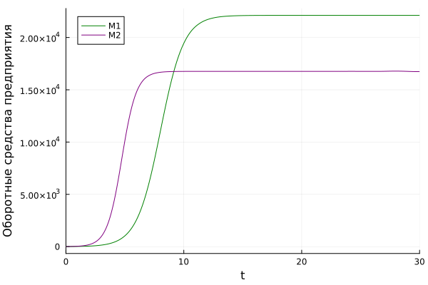

График изменения оборотных средств фирмы 1 и фирмы 2

## Реализация на Julia. Случай 2

```julia
function f(u, p, t)
    M1, M2 = u
    a1, a2, b, c1, c2 = p
    M1 = M1 - (a1/c1)*M1^2 - (b/c1+0.00015)*M1*M2
    M2 = (c2/c1)*M2 - (a2/c1)*M2^2 - (b/c1)*M1*M2
    return [M1, M2]
end
```

## Реализация на Julia. Случай 2

```julia
prob = ODEProblem(f, u0, tspan, p)
sol = solve(prob, Tsit5(), saveat = 0.01)
plot(sol, yaxis = "Оборотные средства предприятия", label = ["M1" "M2"],
          c = ["green" "purple"])
```

## Реализация на Julia. Случай 2

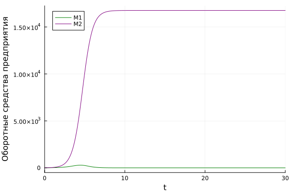

График изменения оборотных средств фирмы 1 и фирмы 2

## Реализация на Julia. Случай 2.

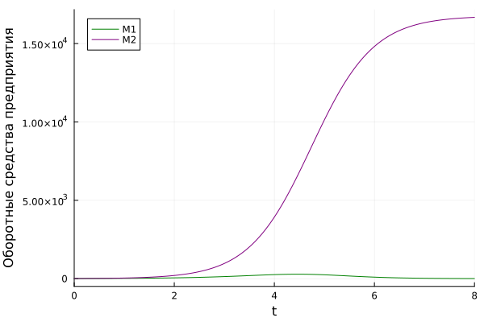

График изменения оборотных средств фирмы 1 и фирмы 2

## Реализация на OpenModelica. Случай 1

```
  parameter Real p_cr = 42;
  parameter Real tau1 = 28;
  parameter Real p1 = 13;
  parameter Real tau2 = 25;
  parameter Real p2 = 10;
  parameter Real N = 88;
  parameter Real q = 1;
  parameter Real a1 = p_cr/(tau1^2*p1^2*N*q);
  parameter Real a2 = p_cr/(tau2^2*p2^2*N*q);
  parameter Real b = p_cr/(tau1^2*tau2^2*p1^2*p2^2*N*q);
  parameter Real c1 = (p_cr-p1)/(tau1*p1);
  parameter Real c2 = (p_cr-p2)/(tau2*p2);
  Real M1(start=7.3);
  Real M2(start=8.3);
```

## Реализация на OpenModelica. Случай 1

```
equation
  der(M1) = M1 - (a1/c1)*M1^2 - (b/c1)*M1*M2;
  der(M2) = (c2/c1)*M2 - (a2/c1)*M2^2 - (b/c1)*M1*M2;
```

## Реализация на OpenModelica. Случай 1

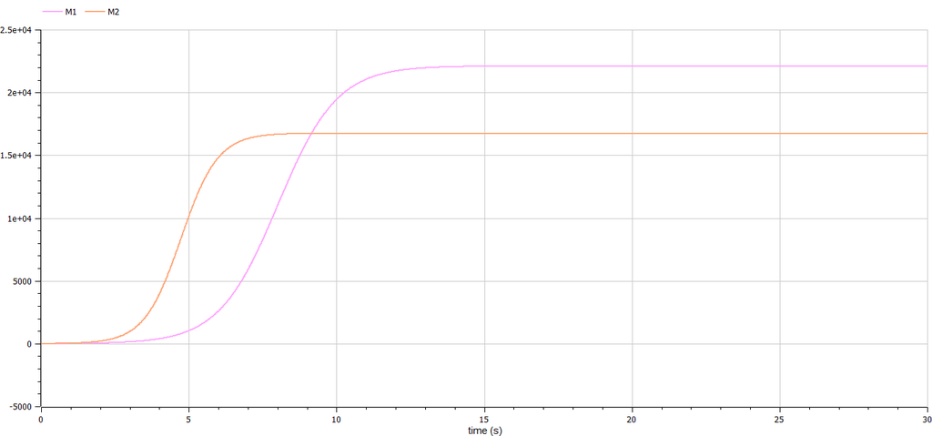

График изменения оборотных средств фирмы 1 и фирмы 2

## Реализация на OpenModelica. Случай 2

```
  parameter Real p_cr = 42;
  parameter Real tau1 = 28;
  parameter Real p1 = 13;
  parameter Real tau2 = 25;
  parameter Real p2 = 10;
  parameter Real N = 88;
  parameter Real q = 1;
  parameter Real a1 = p_cr/(tau1^2*p1^2*N*q);
  parameter Real a2 = p_cr/(tau2^2*p2^2*N*q);
  parameter Real b = p_cr/(tau1^2*tau2^2*p1^2*p2^2*N*q);
  parameter Real c1 = (p_cr-p1)/(tau1*p1);
  parameter Real c2 = (p_cr-p2)/(tau2*p2);
  Real M1(start=7.3);
  Real M2(start=8.3);
```

## Реализация на OpenModelica. Случай 2

```
equation
  der(M1) = M1 - (a1/c1)*M1^2 - (b/c1+0.00015)*M1*M2;
  der(M2) = (c2/c1)*M2 - (a2/c1)*M2^2 - (b/c1)*M1*M2;
```

## Реализация на OpenModelica. Случай 2

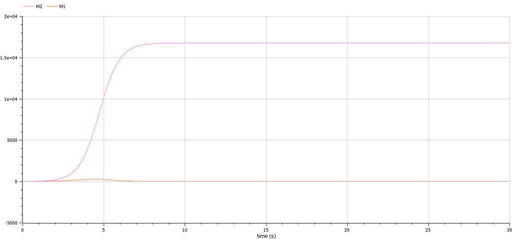

График изменения оборотных средств фирмы 1 и фирмы 2

## Реализация на OpenModelica. Случай 2

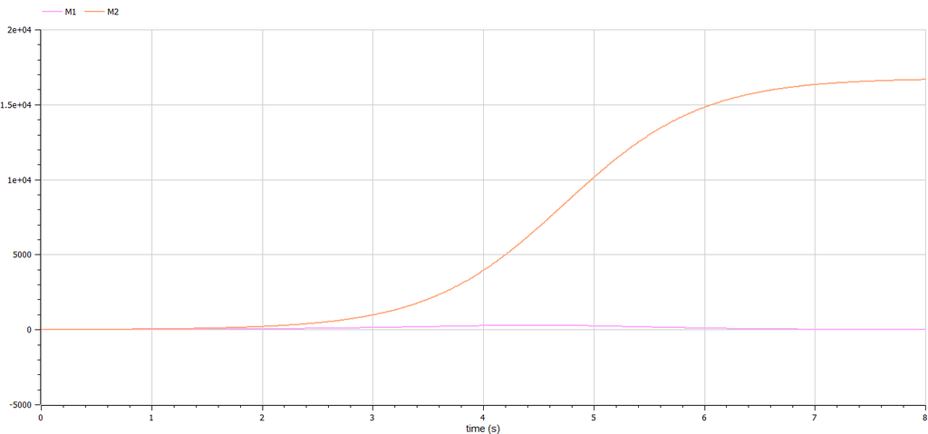

График изменения оборотных средств фирмы 1 и фирмы 2

# Выводы

В результате выполнения лабораторной работы была исследована модель конкуренции двух фирм.

## Список литературы

1. Копылов А.В., Просвиров А.Э. ДИНАМИЧЕСКАЯ МОДЕЛЬ КОНКУРЕНЦИИ ДВУХ ФИРМ НА ОДНОРОДНОМ РЫНКЕ. 2003. 29-32 с.